# Reproducible Research - Peer Assessment 2

Monday, March 08, 2015

# What events do most marm according to U.S. National Oceanic and Atmospheric Administration’s (NOAA) storm database ?

## Synopsis

Since storms and other severe weather events can cause both public health and economic problems for communities and municipalities. Many severe events can result in fatalities, injuries, and property damage, and preventing such outcomes to the extent possible is a key concern. This document tries to analyze and answer specific questions regarding which events are most harmful with respect to population health and which have the greatest economic consequences.

## Data

The data is taken from NOAA Storm Database , which can be downloaded at this link : “http://d396qusza40orc.cloudfront.net/repdata%2Fdata%2FStormData.csv.bz2”

## Data Processing

The analysis was done as follows :

### Load the data :

```r
if (!(require("R.utils", character.only=T, quietly=T))) {
    install.packages("R.utils")
    library("R.utils", character.only=T)
}
```

```r
if(!file.exists("./repdata_data_StormData.csv")){
                download.file("http://d396qusza40orc.cloudfront.net/repdata%2Fdata%2FStormData.csv.bz2","repdata_data_StormData.csv.bz2")
                bunzip2("repdata_data_StormData.csv.bz2")
                }
data <- read.csv("repdata_data_StormData.csv")
print("Loaded")
```

```
## [1] "Loaded"
```

```r
names(data)
```

```
##  [1] "STATE__"    "BGN_DATE"   "BGN_TIME"   "TIME_ZONE"  "COUNTY"
##  [6] "COUNTYNAME" "STATE"      "EVTYPE"     "BGN_RANGE"  "BGN_AZI"
## [11] "BGN_LOCATI" "END_DATE"   "END_TIME"   "COUNTY_END" "COUNTYENDN"
## [16] "END_RANGE"  "END_AZI"    "END_LOCATI" "LENGTH"     "WIDTH"
## [21] "F"          "MAG"        "FATALITIES" "INJURIES"   "PROPDMG"
## [26] "PROPDMGEXP" "CROPDMG"    "CROPDMGEXP" "WFO"        "STATEOFFIC"
## [31] "ZONENAMES"  "LATITUDE"   "LONGITUDE"  "LATITUDE_E" "LONGITUDE_"
## [36] "REMARKS"    "REFNUM"
```

Now let’s select the relevant columns :

```r
p_data <- data[, c("EVTYPE", "FATALITIES", "INJURIES")]
e_data <- data[, c("EVTYPE", "PROPDMG", "PROPDMGEXP", "CROPDMG", "CROPDMGEXP")]
```

Modify the e_data levels

```r
levels(e_data$PROPDMGEXP)
```

```
##  [1] ""  "-" "?" "+" "0" "1" "2" "3" "4" "5" "6" "7" "8" "B" "h" "H" "K"
## [18] "m" "M"
```

```r
levels(e_data$CROPDMGEXP)
```

```
## [1] ""  "?" "0" "2" "B" "k" "K" "m" "M"
```

```r
levels(e_data$PROPDMGEXP)[levels(e_data$PROPDMGEXP)=="-" | levels(e_data$PROPDMGEXP)=="+" | levels(e_data$PROPDMGEXP)=="?" | levels(e_data$PROPDMGEXP)==""] <- 0

levels(e_data$CROPDMGEXP)[levels(e_data$CROPDMGEXP)=="-" | levels(e_data$CROPDMGEXP)=="+" | levels(e_data$CROPDMGEXP)=="?" | levels(e_data$CROPDMGEXP)==""] <- 0

levels(e_data$PROPDMGEXP)[levels(e_data$PROPDMGEXP)=="B" | levels(e_data$PROPDMGEXP)=="b"] <- 9
levels(e_data$PROPDMGEXP)[levels(e_data$PROPDMGEXP)=="H" | levels(e_data$PROPDMGEXP)=="h"] <- 2
levels(e_data$PROPDMGEXP)[levels(e_data$PROPDMGEXP)=="K" | levels(e_data$PROPDMGEXP)=="k"] <- 3
levels(e_data$PROPDMGEXP)[levels(e_data$PROPDMGEXP)=="M" | levels(e_data$PROPDMGEXP)=="m"] <- 6

levels(e_data$CROPDMGEXP)[levels(e_data$CROPDMGEXP)=="B" | levels(e_data$CROPDMGEXP)=="b"] <- 9
levels(e_data$CROPDMGEXP)[levels(e_data$CROPDMGEXP)=="H" | levels(e_data$CROPDMGEXP)=="h"] <- 2
levels(e_data$CROPDMGEXP)[levels(e_data$CROPDMGEXP)=="K" | levels(e_data$CROPDMGEXP)=="k"] <- 3
levels(e_data$CROPDMGEXP)[levels(e_data$CROPDMGEXP)=="M" | levels(e_data$CROPDMGEXP)=="m"] <- 6

levels(e_data$PROPDMGEXP)
```

```
##  [1] "0" "1" "2" "3" "4" "5" "6" "7" "8" "9"
```

```r
levels(e_data$CROPDMGEXP)
```

```
## [1] "0" "2" "9" "3" "6"
```

Calculating the total damage cost

```r
e_data$CROPDMG <- e_data$CROPDMG*10^ as.numeric(e_data$CROPDMGEXP)
e_data$PROPDMG <- e_data$PROPDMG*10^ as.numeric(e_data$PROPDMGEXP)
```

And summerize

```r
fatal_data <- aggregate(FATALITIES ~ EVTYPE, p_data, sum)
inj_data <- aggregate(INJURIES ~ EVTYPE, p_data, sum)
fatal_data_ord <- fatal_data[order(fatal_data$FATALITIES, decreasing=T),]
inj_data_ord <- inj_data[order(inj_data$INJURIES, decreasing=T),]

crop_data <- aggregate(CROPDMG ~ EVTYPE, e_data, sum)
prop_data <- aggregate(PROPDMG ~ EVTYPE, e_data, sum)
crop_data_ord <- crop_data[order(crop_data$CROPDMG, decreasing=T),]
prop_data_ord <- prop_data[order(prop_data$PROPDMG, decreasing=T),]
```

## Results

Load packages

```r
if (!(require("lattice", character.only=T, quietly=T))) {
    install.packages("lattice")
    library("lattice", character.only=T)
}

if (!(require("gridExtra", character.only=T, quietly=T))) {
    install.packages("gridExtra")
    library("gridExtra", character.only=T)
}
```

### 1. Across the United States, which types of events are most harmful with respect to population health?

```r
number_of_events <- 7
head(fatal_data_ord,number_of_events)
```

```
##             EVTYPE FATALITIES
## 834        TORNADO       5633
## 130 EXCESSIVE HEAT       1903
## 153    FLASH FLOOD        978
## 275           HEAT        937
## 464      LIGHTNING        816
## 856      TSTM WIND        504
## 170          FLOOD        470
```

```r
head(inj_data_ord,number_of_events)
```

```
##             EVTYPE INJURIES
## 834        TORNADO    91346
## 856      TSTM WIND     6957
## 170          FLOOD     6789
## 130 EXCESSIVE HEAT     6525
## 464      LIGHTNING     5230
## 275           HEAT     2100
## 427      ICE STORM     1975
```

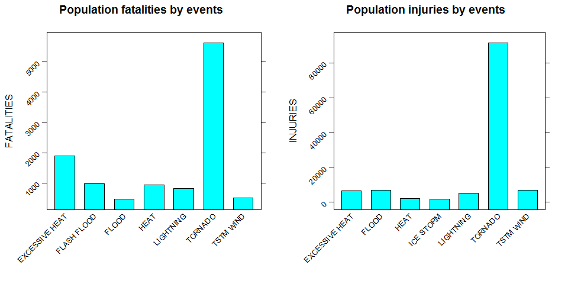

```r
f_p<-barchart(FATALITIES ~ EVTYPE,fatal_data_ord[1:number_of_events,], horizontal = FALSE, main = "Population fatalities by events",scales = list(rot = 45))
i_p<-barchart(INJURIES ~ EVTYPE,inj_data_ord[1:number_of_events,], horizontal = FALSE, main = "Population injuries by events",scales = list(rot = 45))
grid.arrange(f_p, i_p, nrow=1, ncol=2)
```

### 2. Across the United States, which types of events have the greatest economic consequences?

```r
number_of_events <- 7
head(crop_data_ord,number_of_events)
```

```
##                EVTYPE    CROPDMG
## 244              HAIL 6016127730
## 170             FLOOD 2175327500
## 153       FLASH FLOOD 1903907000
## 95            DROUGHT 1459573500
## 856         TSTM WIND 1132098500
## 834           TORNADO 1026973700
## 760 THUNDERSTORM WIND  699270500
```

```r
head(prop_data_ord,number_of_events)
```

```
##                EVTYPE      PROPDMG
## 170             FLOOD 1.446577e+12
## 411 HURRICANE/TYPHOON 6.930584e+11
## 834           TORNADO 5.694738e+11
## 670       STORM SURGE 4.332354e+11
## 153       FLASH FLOOD 1.682267e+11
## 244              HAIL 1.573527e+11
## 402         HURRICANE 1.186832e+11
```

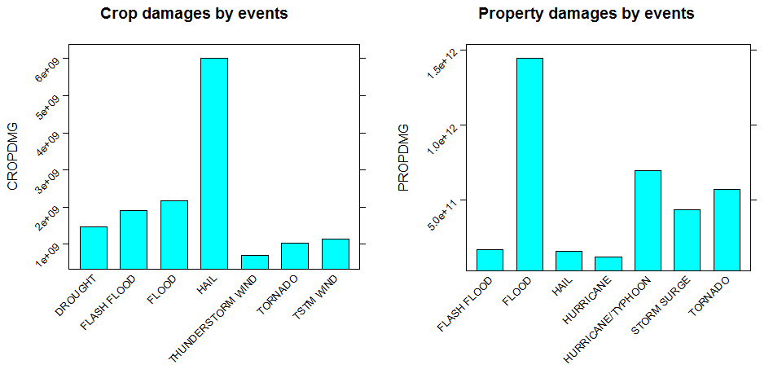

```r
c_p<-barchart(CROPDMG ~ EVTYPE,crop_data_ord[1:number_of_events,], horizontal = FALSE, main = "Crop damages by events",scales = list(rot = 45))
p_p<-barchart(PROPDMG ~ EVTYPE,prop_data_ord[1:number_of_events,], horizontal = FALSE, main = "Property damages by events",scales = list(rot = 45))
grid.arrange(c_p, p_p, nrow=1, ncol=2)
```